# Functional analysis of regulated psites upon TCR stimulation

Marie Locard-Paulet

Tue Oct 23 10:34:55 2018

This document contains the functional analysis of proteomic data set described in the document `DataPreparation_Proteome`. I used the LFQ-normalised quantification values for the statistical test (see `StatisticalAnalysis/StatisticalAnalysisProteins`).

# Filters and statistical analysis

See the data preparation in the document `DataPreparation_Proteome` (this document contains QC plots).

I cleaned-up the data as follows:

- Remove the Protein.IDs fields containing CON_ or _REV.
- Remove the proteins with 0 or 1 unique peptide identified.
- Replace the 0 LFQ values with NA.

I log2-transform the data set. For each replicate independently, I calculate the mean of the injection replicates in each time point.

From there, I run a loop of 200 iterations that contain the following steps:

For each protein, I replace missing values with a random value generated around the 5% quantile of the intensities for each condition, using the standard deviation of the dataset (technical variance) for each condition.

For each protein, I normalise the biological replicates using the median of the signal across all the conditions (before replacement of missing values).

I perform an anova on each protein site across the 6 time points. Then, I correct the pvalue with Tukey HSD.

I calculate the fold changes per time point relative to each other.

The thresholds for a protein to be regulated is having a pvalue of the Anova under or equal to 0.05, and the best pvalue from Tukey under or equal to 0.05 with a corresponding absolute log2-transformed fold change above or equal to log2(1.75).

This is performed 200 times, then I keep as variants only the sites that pass these threshold a minimum of 90% of the times. All the fold change values reported are the averages of the 200 iterations.

# Results of the statistical analysis

```r
Prottab <- read.table("SupTables/ProtfinalStat.txt", sep = "\t", header = T)
```

# Volcano plots of the anova:

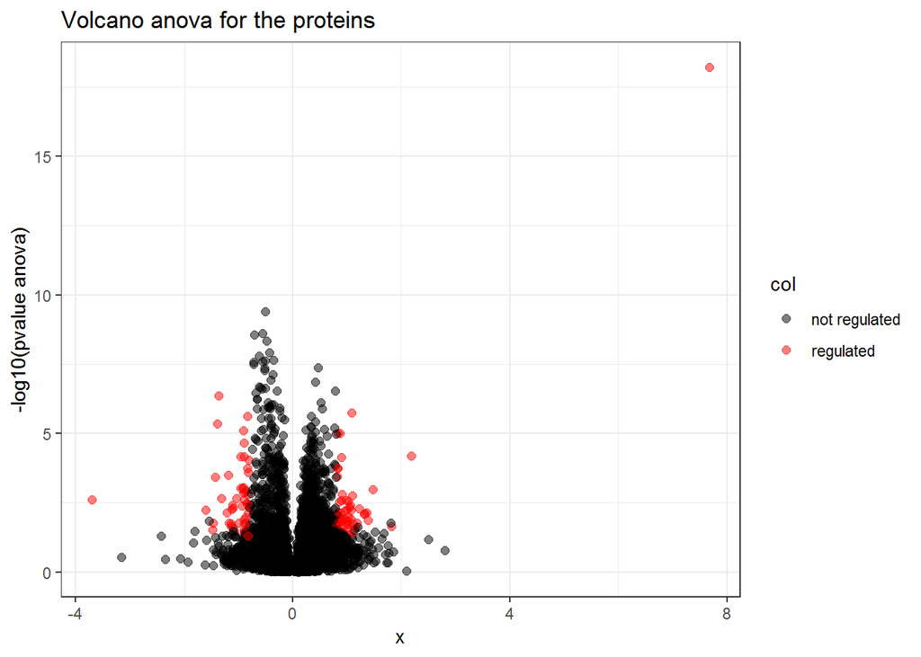

```r
tab <- Prottab
tab <- tab[!is.na(tab$pAnova),]
matFC <- tab[,grepl(".FC", names(tab), fixed = T)]
# Calculate the maximum fold changes:
vec <- rep(NA, nrow(matFC))
for (j in 1:nrow(matFC)) {
  v <- as.numeric(matFC[j,])
  if (length(v)>0) {
    vm <- max(abs(v))
    vec[j] <- v[abs(v)==vm][1]
  }
}

labels <- as.character(tab$Majority.protein.IDs[tab$Regulation])
labs <- rep(NA, nrow(tab))
labs[tab$Majority.protein.IDs %in% labels] <- labels
gtab <- data.frame(tab, "y"=-(log10(as.numeric(as.character(tab$pAnova)))), "col" = ifelse(tab$Regulation, "regulated", "not regulated"), "x" = vec, "Prot" = labs)
ti <- paste0("Volcano anova for the proteins")
g <- ggplot(data = gtab, aes(x = x, y = y, col = col, label = Prot)) + geom_point(alpha = 0.5, size = 2) + scale_color_manual(values = c("black", "red")) + ylab("-log10(pvalue anova)") + ggtitle(ti) + theme_bw()# + geom_text_repel()
print(g)
```

```r
na <- paste0("Figures/Anova_Proteins.pdf")
pdf(na, useDingbats=FALSE, 11.69, 8.27)
print(g)
dev.off()
```

```r
print("Number of regulated proteins:")
```

```
## [1] "Number of regulated proteins:"
```

```r
treg <- table(gtab$col)
kable(cbind(names(treg), treg))
```

|  |  | treg |
| --- | --- | --- |
| not regulated | not regulated | 3735 |
| regulated | regulated | 105 |

I also draw the volcano plots per time point in order to get a feel for the statistics at each time point. These are saved in `Figures`.

# Regulated proteins

The regulated proteins are: sp|A2A432|CUL4B_MOUSE, sp|A2AM29|AF9_MOUSE, sp|O35405|PLD3_MOUSE, sp|O54833|CSK22_MOUSE, sp|O70126|AURKB_MOUSE, sp|O70445|BARD1_MOUSE, sp|O70456|1433S_MOUSE, sp|O88351|IKKB_MOUSE, sp|O88895|HDAC3_MOUSE, sp|P01864|GCAB_MOUSE;sp|P01863|GCAA_MOUSE;sp|P01865|GCAM_MOUSE, sp|P09671|SODM_MOUSE, sp|P09925|SURF1_MOUSE, sp|P0C7N9|PSMG4_MOUSE, sp|P15535|B4GT1_MOUSE, sp|P22892|AP1G1_MOUSE, sp|P22935|RABP2_MOUSE, sp|P29452|CASP1_MOUSE, sp|P31041|CD28_MOUSE, sp|P33174|KIF4_MOUSE, sp|P35293|RAB18_MOUSE, sp|P49443|PPM1A_MOUSE, sp|P52912|TIA1_MOUSE, sp|P55302|AMRP_MOUSE, sp|P56212|ARP19_MOUSE, sp|P56671|MAZ_MOUSE, sp|P59016|VP33B_MOUSE, sp|P60898|RPB9_MOUSE, sp|P61025|CKS1_MOUSE, sp|P61211|ARL1_MOUSE, sp|P62313|LSM6_MOUSE, sp|P63254|CRIP1_MOUSE, sp|P70445|4EBP2_MOUSE, sp|P83870|PHF5A_MOUSE, sp|P85094|ISC2A_MOUSE, sp|P97470|PP4C_MOUSE, sp|Q08024|PEBB_MOUSE, sp|Q3TAA7|S11IP_MOUSE, sp|Q3TYX3|SMYD5_MOUSE, sp|Q3UGR5|HDHD2_MOUSE, sp|Q3UIA2|RHG17_MOUSE, sp|Q4KML4|ABRAL_MOUSE, sp|Q571H0|NPA1P_MOUSE, sp|Q5BLK4|TUT7_MOUSE, sp|Q5SFM8|RBM27_MOUSE, sp|Q5SV85|SYNRG_MOUSE, sp|Q60692|PSB6_MOUSE, sp|Q61102|ABCB7_MOUSE, sp|Q61142|SPIN1_MOUSE, sp|Q61458|CCNH_MOUSE, sp|Q61490|CD166_MOUSE, sp|Q62137|JAK3_MOUSE, sp|Q6A0A2|LAR4B_MOUSE, sp|Q6PA06|ATLA2_MOUSE, sp|Q6PGG2|GMIP_MOUSE, sp|Q75NR7|RECQ4_MOUSE, sp|Q791V5|MTCH2_MOUSE, sp|Q7TS74|CKP2L_MOUSE, sp|Q7TSV4|PGM2_MOUSE, sp|Q8BGD8|COA6_MOUSE, sp|Q8BGS7|CEPT1_MOUSE, sp|Q8BHB4|WDR3_MOUSE, sp|Q8BHN5|RBM45_MOUSE, sp|Q8BNV1|TRM2A_MOUSE, sp|Q8BSN5|PHF23_MOUSE, sp|Q8BU31|RAP2C_MOUSE;sp|Q80ZJ1|RAP2A_MOUSE, sp|Q8BUH8|SENP7_MOUSE, sp|Q8BUI3|LRWD1_MOUSE, sp|Q8BWZ3|NAA25_MOUSE, sp|Q8BY71|HAT1_MOUSE, sp|Q8C0D5|ETUD1_MOUSE, sp|Q8C3P7|MTA70_MOUSE, sp|Q8CBY8|DCTN4_MOUSE, sp|Q8CFK6|DEN1C_MOUSE, sp|Q8K2V1|PP4R1_MOUSE, sp|Q8QZY9|SF3B4_MOUSE, sp|Q8R349|CDC16_MOUSE, sp|Q8R3C6|RBM19_MOUSE, sp|Q8R5F7|IFIH1_MOUSE, sp|Q8VD62|CK068_MOUSE, sp|Q91XD6|VPS36_MOUSE, sp|Q91XI1|DUS3L_MOUSE, sp|Q91YR1|TWF1_MOUSE, sp|Q921Y2|IMP3_MOUSE, sp|Q99JW4|LIMS1_MOUSE;sp|Q91XD2|LIMS2_MOUSE, sp|Q99KB8|GLO2_MOUSE, sp|Q99LN9|DOHH_MOUSE, sp|Q99LR1|ABD12_MOUSE, sp|Q99NB8|UBQL4_MOUSE, sp|Q99PG2|OGFR_MOUSE, sp|Q9CQ22|LTOR1_MOUSE, sp|Q9CQL7|MOFA1_MOUSE, sp|Q9CQT2|RBM7_MOUSE, sp|Q9CR80|FA32A_MOUSE, sp|Q9CWW6|PIN4_MOUSE, sp|Q9CY50|SSRA_MOUSE, sp|Q9D2C2|SAAL1_MOUSE, sp|Q9D358|PPAC_MOUSE, sp|Q9D5V5|CUL5_MOUSE, sp|Q9DB29|IAH1_MOUSE, sp|Q9EPV8|UBL5_MOUSE, sp|Q9EQ80|GTPC1_MOUSE, sp|Q9ERA6|TFP11_MOUSE, sp|Q9JHJ3|GLMP_MOUSE, sp|Q9R0I7|YLPM1_MOUSE, sp|Q9WUB4|DCTN6_MOUSE.

Heatmap:

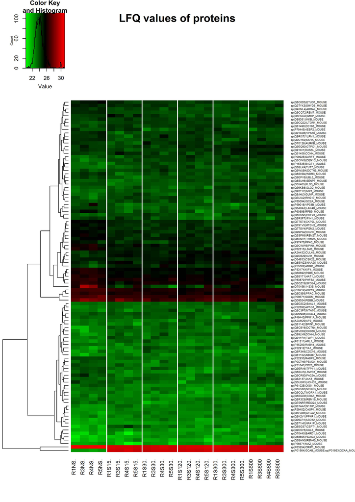

# Number of phosphorylation site per protein

```r
load(file = "RData/11_TableClusters.RData")
load(file = "RData/03_psiteInfoPhosphoSitePlus.RData")
load(file = "RData/05_ParsedTablesNormPSP.RData")

phostab <- export
rm(export)
phostab$Accession <- sapply(phostab$psiteID, function(x) {
  strsplit(as.character(x), "_", fixed = T)[[1]][1]
})
```

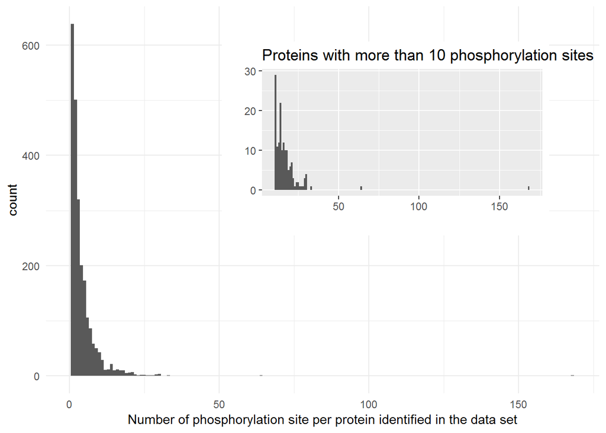

# Phosphorylation site relative to protein quantification

When a phosphorylation site matches to several proteins, I take the first one that comes out.

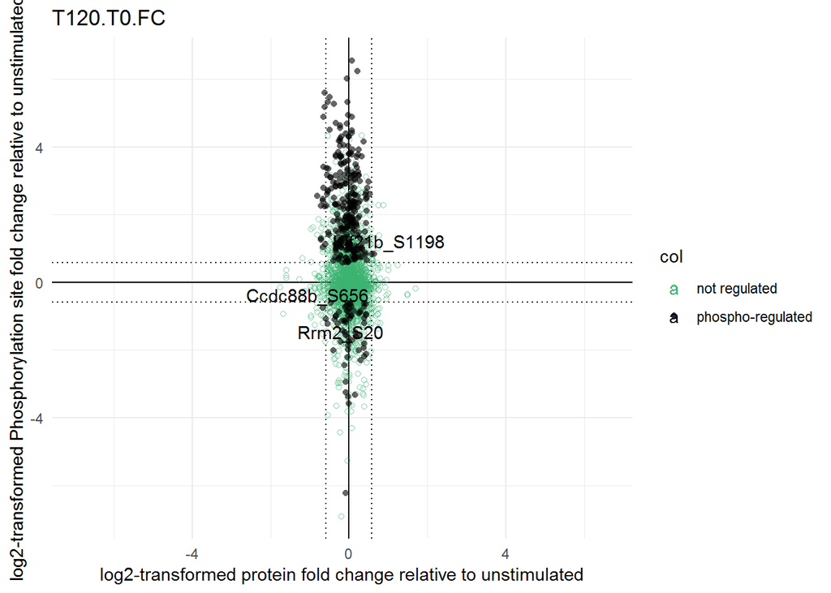

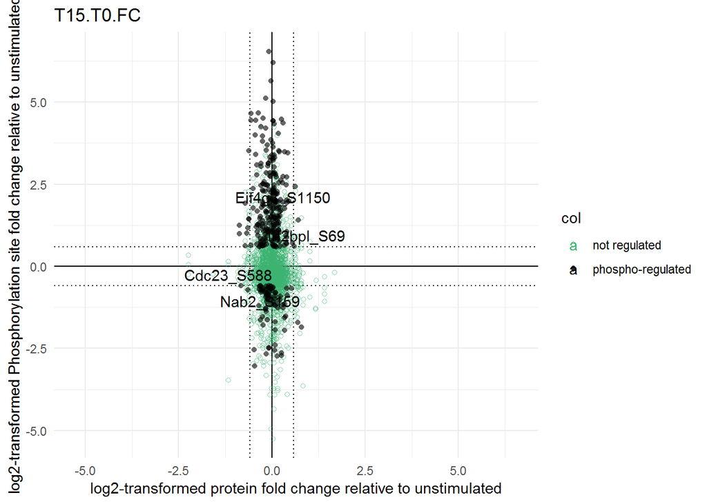

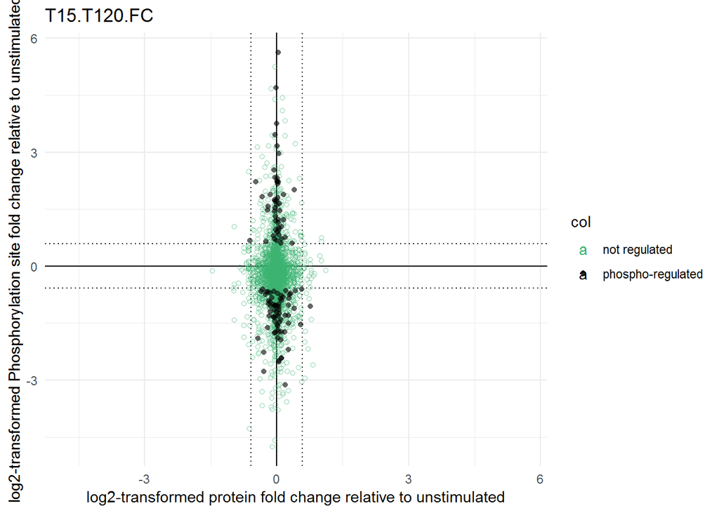

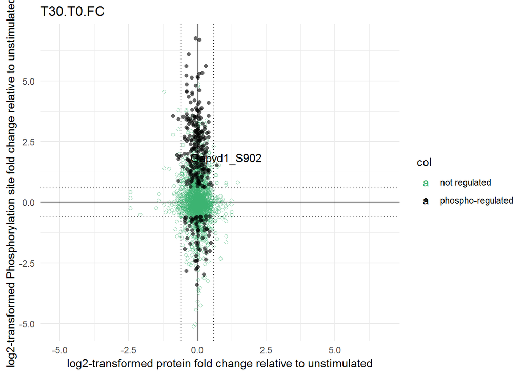

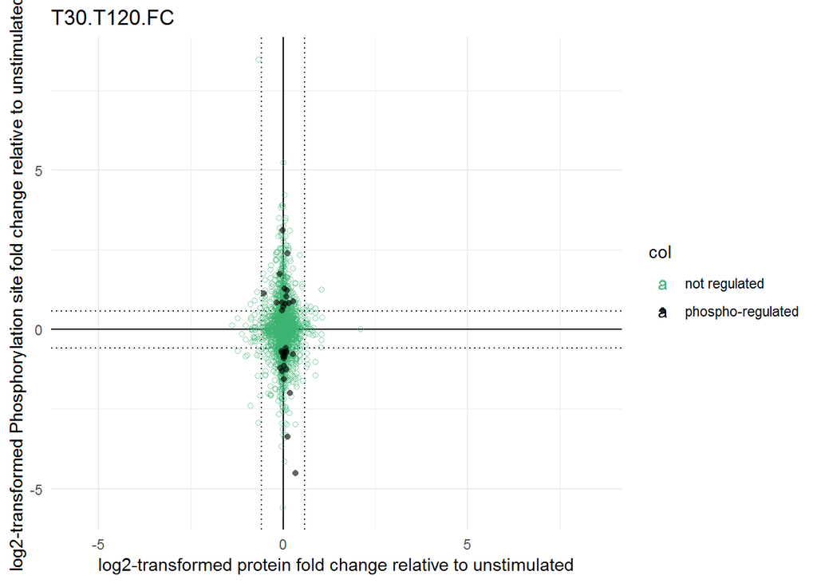

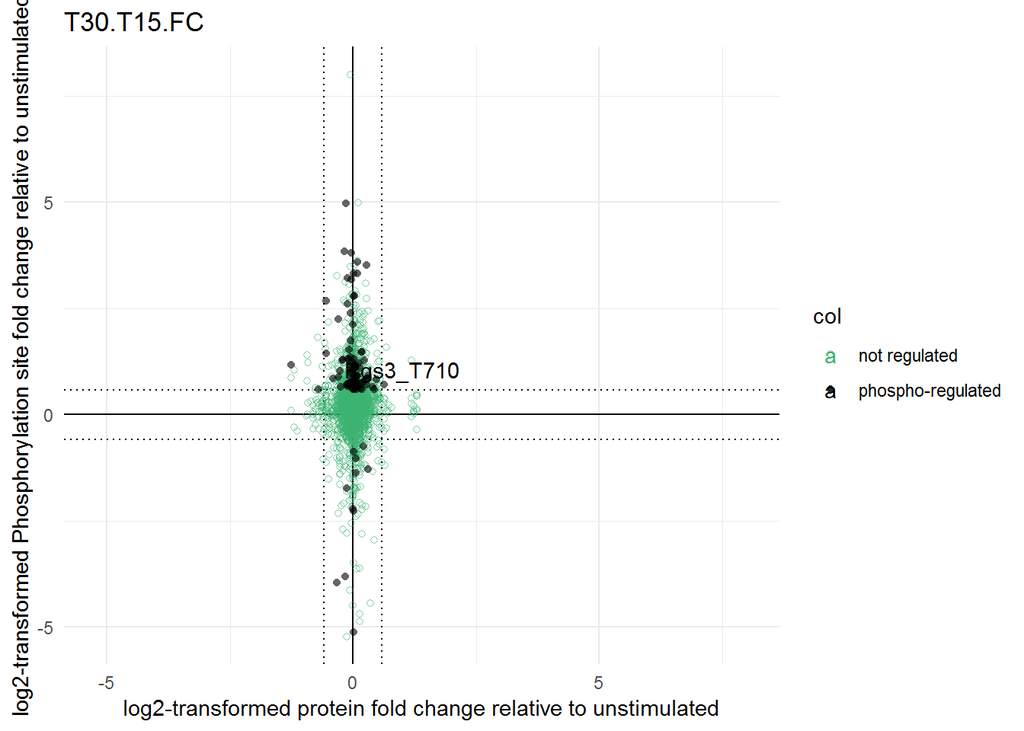

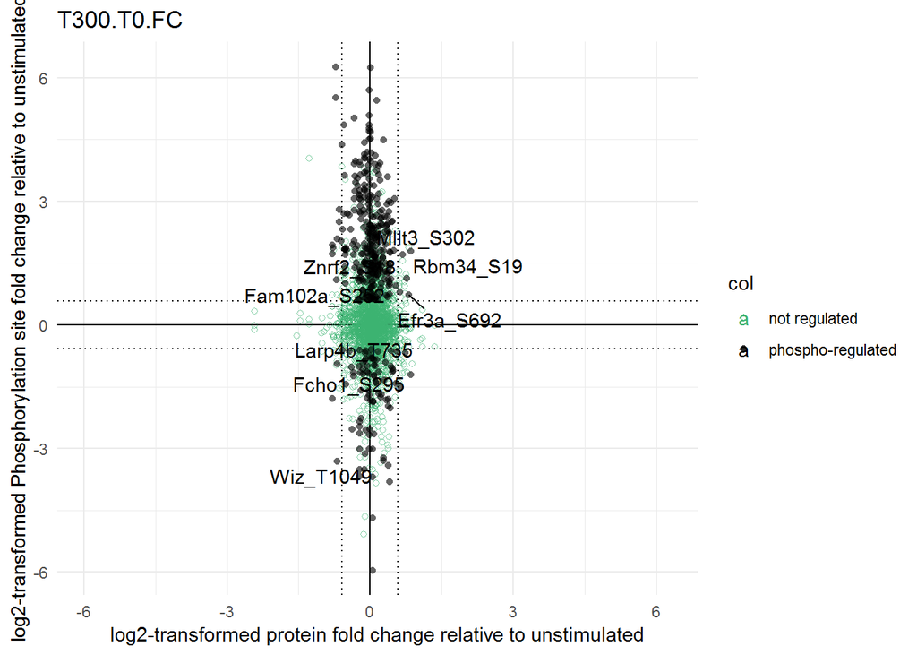

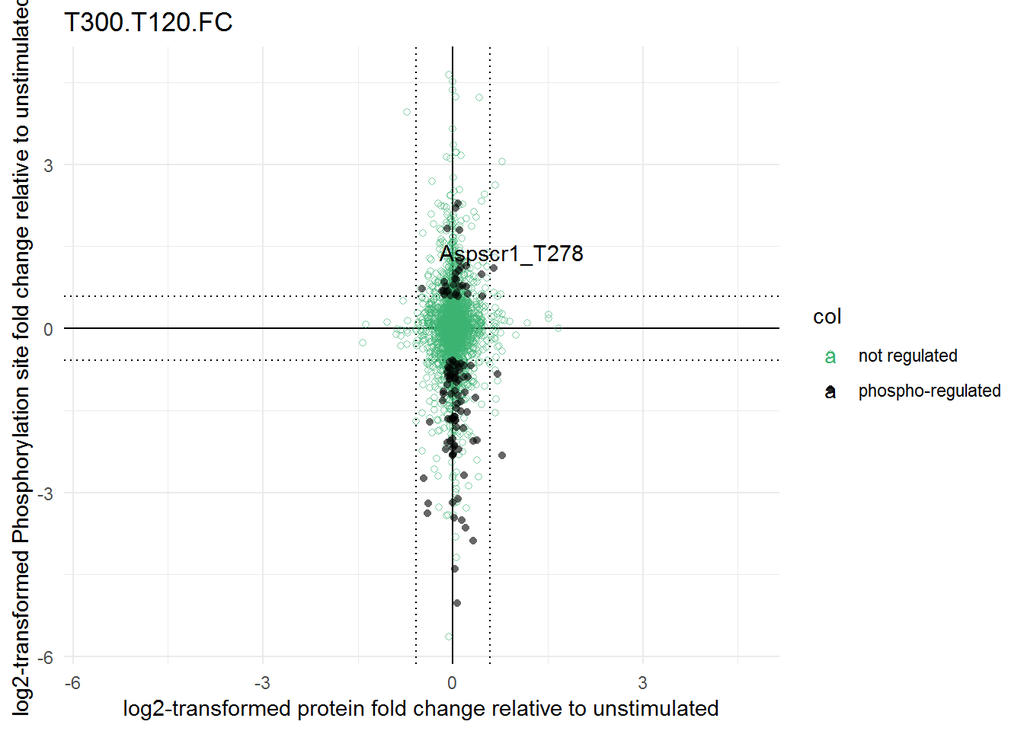

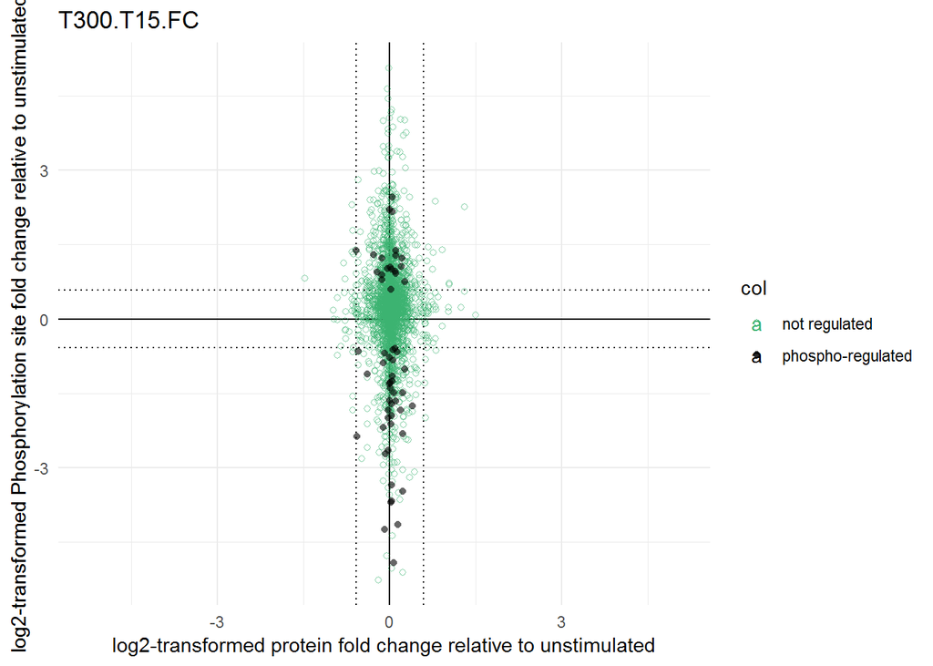

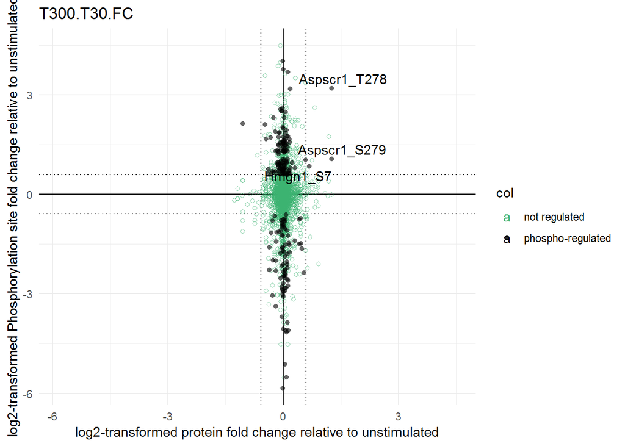

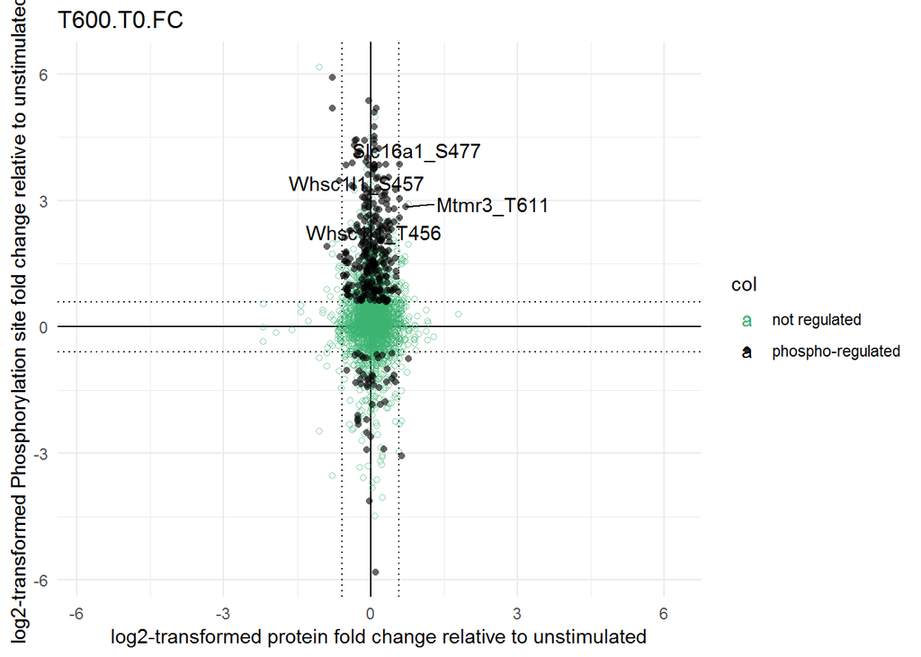

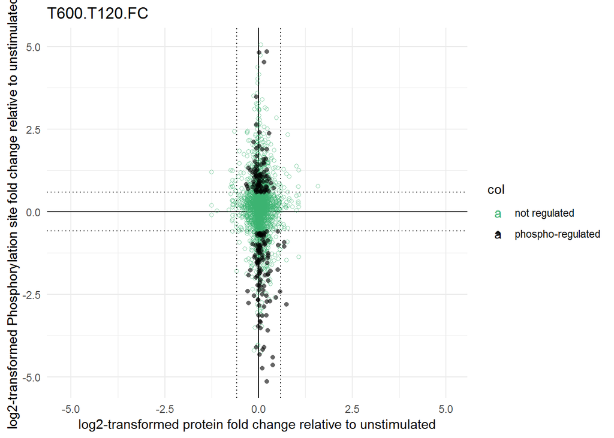

[3 more figures not shown]

There is 79.94% of the phosphorylation sites (mono and multi) with an available protein quantification.

A few of the regulated phosphorylation sites have a FC that correlates slightly with the corresponding protein. These are: Agap2_S921, Akt2_T451, Aspscr1_S279, Aspscr1_T278, Bach2_S314, Ccdc88b_S656, Cdc23_S588, Daxx_S515, Efr3a_S692, Eif4g3_S1150, Fam102a_S252, Fcho1_S295, Gapvd1_S902, Hmgn1_S7, Irf2bpl_S69, Kif21b_S1198, Larp4b_T735, Mllt3_S302, Mtmr3_T611, Nab2_S159, Ppp2r5c_S497, Rbm34_S19, Rgs3_S776, Rgs3_T710, Rrm2_S20, Slc16a1_S210+S213, Slc16a1_S477, Svil_S227, Whsc1l1_S457, Whsc1l1_T456, Wiz_T1049, Znrf2_S18. *This only takes into account the fold changes of the proteins, not the pvalue (reproducibility).*

I add this information to the phosphotable.

```r
phostab$WarningProteinFC <- phostab$GeneID %in% suspiciousProt
export <- phostab
save(export, file = "RData/12_PhosphoTableWithProteinWaring.RData")
write.table(export, "SupTables/PhosphoDataWithProtAnalysis.txt", sep = "\t", row.names = F)
```